## Data Load

```python
# Loading data table from csv files.
import pandas as pd
df_VN_data = pd.read_csv('https://storage.googleapis.com/datalynn-datasets/interview-challenge/technology/Microsoft_Azure_Virtual_Network/VNData.csv')
```

# Question 1

**Scenario**: The team suspects some of the resources might have discrepancies in their data, which could be outliers.

**Question**: Given the `Traffic_Volume` and `Connection_Count` from the resources, can you identify possible outliers?

## Solution:

### Hints:

1. **Understand Z-Scores and Outliers**
   - Before diving into the code, ensure you have a solid understanding of z-scores and how they relate to outlier detection. A z-score quantifies the number of standard deviations a data point deviates from the mean. Outliers often exhibit z-scores significantly higher or lower than a chosen threshold. Familiarizing yourself with this concept is essential for effectively identifying outliers in numerical data.
2. **Choose an Outlier Threshold**
   - Carefully consider the determination of outliers by selecting an appropriate z-score threshold (e.g., 2 or 3). The choice of threshold plays a crucial role in this process. Higher thresholds are more lenient and may identify more points as outliers, while lower thresholds are more stringent and might only identify extreme outliers. Your decision should reflect the characteristics of your dataset and the level of sensitivity you require.
3. **Visualize Outliers**
   - Leverage data visualization techniques to gain valuable insights into potential outliers. Creating a scatter plot of the two numerical columns, `Traffic_Volume` and `Connection_Count`, can provide a visual representation of the data distribution. Overlaying the points flagged as potential outliers using distinct colors can facilitate their visual identification. Visualization can help validate whether the identified potential outliers based on z-scores align with observed trends in the scatter plot.

```
Potential Outliers:
     Unnamed: 0  Resource_ID Network_Type  Traffic_Volume  Connection_Count  \
19           19           20      private             298               217
28           28           29       public             269               394
45           45           46      private             270               430
47           47           48       public             263               467
56           56           57      private             289               296
..          ...          ...          ...             ...               ...
912         912          913       public             194               386
920         920          921      private             230               438
937         937          938       public             235               438
984         984          985      private             243               397
999         999         1000      private             267               447

     Error_Rate  Route_Changes Resource_Type  Response_Time  Security_Flag  \
```

[output cut: 26 more lines]

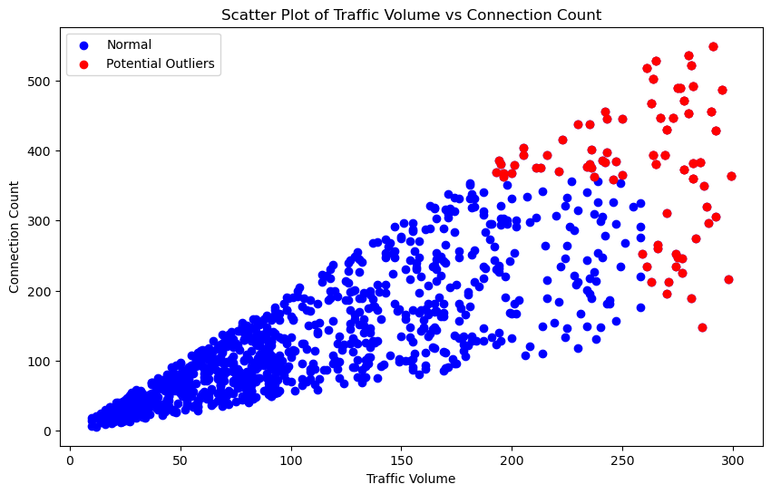

```python
import pandas as pd
import numpy as np
import matplotlib.pyplot as plt

# Step 1: Calculate z-scores for Traffic_Volume and Connection_Count columns
z_scores_traffic = np.abs((df_VN_data['Traffic_Volume'] - df_VN_data['Traffic_Volume'].mean()) / df_VN_data['Traffic_Volume'].std())
z_scores_connection = np.abs((df_VN_data['Connection_Count'] - df_VN_data['Connection_Count'].mean()) / df_VN_data['Connection_Count'].std())

# Step 2: Define a threshold for outlier detection (e.g., z-score > 2)
outlier_threshold = 2

# Step 3: Identify rows with potential outliers based on z-scores
potential_outliers_traffic = df_VN_data[z_scores_traffic > outlier_threshold]
potential_outliers_connection = df_VN_data[z_scores_connection > outlier_threshold]

# Step 4: Combine potential outliers from both columns
all_potential_outliers = pd.concat([potential_outliers_traffic, potential_outliers_connection])

# Step 5: Display the potential outliers
print("Potential Outliers:")
print(all_potential_outliers)

# Step 6: Create scatter plot to visualize potential outliers
plt.figure(figsize=(10, 6))
plt.scatter(df_VN_data['Traffic_Volume'], df_VN_data['Connection_Count'], color='blue', label='Normal')
plt.scatter(all_potential_outliers['Traffic_Volume'], all_potential_outliers['Connection_Count'], color='red', label='Potential Outliers')
plt.xlabel('Traffic Volume')
plt.ylabel('Connection Count')
plt.title('Scatter Plot of Traffic Volume vs Connection Count')
plt.legend()
plt.show()
```

## Summary

By working through this question, you gained practical experience in identifying potential outliers, using z-scores, and visualizing data to validate your findings. These skills are valuable for data analysis and decision-making in various domains.

# Question 2

**Scenario**: With the increasing complexity of digital landscape, we observe certain resources experiencing higher error rates than others.

**Question**: Based on the `Error_Rate`, can you statistically validate if resources from a particular `Region` have a significantly different error rate than others?

## Solution:

### Hints:

1. **Understand Analysis of Variance (ANOVA)**
   - Before delving into the code, understand the concept of Analysis of Variance (ANOVA). ANOVA is a statistical method used to compare means across multiple groups to determine if there are any statistically significant differences among the groups. In this case, you'll be using a one-way ANOVA to compare error rates across different regions.
2. **Grouping and Preparing Data**
   - Focus on how to group your data by Region and extract error rates for each group. This step is crucial for performing the ANOVA test. You need to create separate datasets for each region's error rates.
3. **Choosing Significance Level and Interpreting Results**
   - Decide on a significance level (often denoted as alpha) to make a decision based on the ANOVA results. If the p-value from the ANOVA test is less than the chosen significance level, you'll conclude that there is a significant difference in error rates among regions. In such cases, you might need to perform additional tests (post-hoc tests) to identify specific differences between pairs of regions.

```python
from scipy.stats import f_oneway
# Step 1: Group data by 'Region' and extract error rates for each group
regions = df_VN_data['Region'].unique()
error_rates_by_region = [df_VN_data[df_VN_data['Region'] == region]['Error_Rate'] for region in regions]

# Step 2: Perform one-way ANOVA to test for significant differences in error rates
f_statistic, p_value = f_oneway(*error_rates_by_region)

# Step 3: Define significance level (alpha)
alpha = 0.05

# Step 4: Print ANOVA results and make a decision based on p-value
print("One-way ANOVA results:")
print(f"F-statistic: {f_statistic}")
print(f"P-value: {p_value}")

if p_value < alpha:
    print("There is a significant difference in error rates among regions.")
    # If significant, perform post-hoc tests like Tukey's HSD to identify specific differences.
else:
    print("There is no significant difference in error rates among regions.")
```

```
One-way ANOVA results:
F-statistic: 71.80735665357561
P-value: 4.790632478883341e-42
There is a significant difference in error rates among regions.
```

## Summary

Overall, this question equipped you with the skills to conduct hypothesis testing, interpret statistical results, and draw conclusions about the significance of error rate differences among different regions using the ANOVA method.

# Question 3

**Scenario**: The company wants to predict `Response_Time` based on various features to ensure efficient data flow.

**Question**: Build a model using the provided features, specifying `Response_Time` as the target variable. Evaluate its performance and recommend if any features might be causing overfitting.

## Solution:

### Hints:

1. **Understand Regression and Model Building**
   - Before you begin, ensure you understand the basics of regression analysis and model building. Regression aims to establish a relationship between variables, and in this case, you're predicting `Response_Time` using various features. Familiarize yourself with linear regression and how features impact the target variable.
2. **Feature Selection and Evaluation Metrics**
   - Choose a set of relevant features that might influence `Response_Time`. Carefully consider how different features impact the model's predictive power. Use evaluation metrics like Mean Squared Error (MSE) and R-squared (R2) score to assess the model's performance. A low MSE and a high R2 indicate better performance.
3. **Train-Test Split and Overfitting Check**
   - Split your data into training and testing sets. This allows you to train the model on one subset and evaluate it on another to simulate real-world performance. Compare the model's performance on the training and testing sets. If the training R2 is significantly higher than the testing R2, there might be overfitting. Be cautious of including too many features that could lead to overfitting.

```python
import pandas as pd
import numpy as np
from sklearn.model_selection import train_test_split
from sklearn.linear_model import LinearRegression
from sklearn.metrics import mean_squared_error, r2_score

# Step 1: Prepare feature matrix X and target vector y
features = ['Traffic_Volume', 'Connection_Count', 'Error_Rate', 'Route_Changes', 'Security_Flag']
X = df_VN_data[features]
y = df_VN_data['Response_Time']

# Step 2: Split the data into training and testing sets
X_train, X_test, y_train, y_test = train_test_split(X, y, test_size=0.2, random_state=37)

# Step 3: Build a Linear Regression model
model = LinearRegression()
model.fit(X_train, y_train)

# Step 4: Make predictions on the test set
y_pred = model.predict(X_test)

# Step 5: Evaluate the model's performance
mse = mean_squared_error(y_test, y_pred)
r2 = r2_score(y_test, y_pred)

print("Model Performance:")
print(f"Mean Squared Error (MSE): {mse}")
print(f"R-squared (R2) Score: {r2}")

# Step 6: Check for potential overfitting by comparing training and testing performance
y_train_pred = model.predict(X_train)
train_mse = mean_squared_error(y_train, y_train_pred)
train_r2 = r2_score(y_train, y_train_pred)

print("\nTraining Performance:")
print(f"Train Mean Squared Error (MSE): {train_mse}")
print(f"Train R-squared (R2) Score: {train_r2}")

# Step 7: Recommend if any features might be causing overfitting
if train_r2 > r2:
    print("\nRecommendation: The model might be overfitting. Consider evaluating and potentially removing some features.")
else:
    print("\nRecommendation: The model shows balanced performance and does not appear to be overfitting.")
```

```
Model Performance:
Mean Squared Error (MSE): 7.031096426679346
R-squared (R2) Score: 0.9986067732636088

Training Performance:
Train Mean Squared Error (MSE): 6.554961107951642
Train R-squared (R2) Score: 0.9985556781724662

Recommendation: The model shows balanced performance and does not appear to be overfitting.
```

## Summary

In conclusion, you gained hands-on experience in building predictive models, evaluating their performance, and considering the potential pitfalls of overfitting. These skills are valuable for data analysis and decision-making in diverse contexts.

# Question 4

**Scenario**: Azure aims to launch a new feature for the Virtual Network.

**Question**: Given the data, how would you design a system that can automatically redirect traffic or change routes when the `Error_Rate` goes above a certain threshold? Additionally, prioritize between speed of delivery and quality of this end product.

## Solution:

### Hints:

1. **Data Integration and Real-Time Monitoring**
   - To build a system that reacts to changing conditions, you need to integrate with real-time data sources that provide the Error_Rate. Consider how to fetch this data and update it regularly. You can use libraries like pandas for data handling and design a loop to monitor the data at intervals.
2. **Decision Logic and Prioritization**
   - Think about the decision-making logic based on the Error_Rate and the defined threshold. If the error rate exceeds the threshold, you'll need to decide whether to prioritize fast redirection or quality through route changes. Prioritization involves comparing the specified priorities for speed and quality.
3. **Decision Logic and Prioritization**
   - Before implementing the system with live data and real traffic, consider testing and simulation. You can simulate fetching error rate data, making decisions, and observing how the system reacts. This allows you to fine-tune the threshold and priorities, ensuring the system behaves as intended when deployed in a live environment.

```python
import time

# Constants for threshold and priorities
ERROR_RATE_THRESHOLD = 2.0
SPEED_PRIORITY = 0.6
QUALITY_PRIORITY = 0.4

def monitor_error_rate(debug=True):
    while True:
        # Simulate fetching error rate data from the source (e.g., API, database)
        current_error_rate = fetch_error_rate()

        if current_error_rate > ERROR_RATE_THRESHOLD:
            print(f"Error rate is above the threshold: {current_error_rate}")
            if SPEED_PRIORITY > QUALITY_PRIORITY:
                redirect_traffic_fast()
            else:
                change_routes_for_quality()
        else:
            print(f"Error rate is below the threshold: {current_error_rate}")

        if debug == True:
            break
        # Wait for a specific interval before checking again
        time.sleep(10)

def fetch_error_rate():
    # Simulate fetching the error rate from a data source
    # Replace this with actual code to fetch error rate
    return 2.5

def redirect_traffic_fast():
    # Logic to quickly redirect traffic to mitigate issues
    print("Redirecting traffic quickly for speedy recovery")

def change_routes_for_quality():
    # Logic to change routes considering quality
    print("Changing routes to ensure quality")

# Start monitoring error rate
# To avoid the infinity loop, we set a debug flag.
monitor_error_rate(debug=True)
```

[output not shown]

### Explanation of Steps:

1. Constants and Priorities: Define constants such as the ERROR_RATE_THRESHOLD and priorities for speed and quality. These priorities are used to decide whether to prioritize speedy redirection or consider route changes for better quality.
2. Monitoring Loop: Create a monitoring loop that continuously fetches the current Error_Rate from a data source. This loop keeps running indefinitely, checking the error rate periodically.
3. Fetching Error Rate: Implement the fetch_error_rate function to simulate fetching the current error rate from a data source. Replace the simulation code with actual code to fetch data.
4. Decision Logic: When the error rate goes above the threshold, the system makes a decision based on priorities. If speed is prioritized over quality, redirect traffic quickly. If quality is prioritized, change routes to ensure better quality.
5. Redirection and Route Change: Implement the redirect_traffic_fast and change_routes_for_quality functions with appropriate logic to handle traffic redirection and route changes.
6. Monitoring Interval: Introduce a delay between error rate checks to avoid constant querying of data sources.
7. Start Monitoring: Initiate the monitoring loop by calling the monitor_error_rate function.

### Priority Consideration:

The decision between speed and quality depends on your priorities. If you choose a higher value for SPEED_PRIORITY, the system will prioritize quick redirection. If you choose a higher value for QUALITY_PRIORITY, the system will prioritize changing routes for better quality. Adjusting these priority values will influence the system's behavior based on your goals.

## Summary

In conclusion, you gained valuable knowledge about designing responsive systems, considering priorities, and handling real-time decision-making based on dynamic data. These skills are applicable in fields ranging from network management to automation and beyond.